# Proyeksi Nilai Tukar USD/IDR Menggunakan GBM & Monte Carlo

Bagian [05]: [Analisis Hasil]

Muhammad Faeruz Wafi Abidin

2026-06-16

> **Tentang Proyek Portofolio Ini**

> Dokumen ini merupakan bagian dari rangkaian analisis peramalan kurs USD/IDR periode 2021–2025 menggunakan pemodelan stokastik **Geometric Brownian Motion (GBM)** dan **Simulasi Monte Carlo**. Proyek ini bertujuan untuk mengestimasi lintasan nilai tukar harian ke depan berdasarkan volatilitas dan *drift* historis.

> **Struktur Publikasi:**
> 1. [Data Wrangling] Persiapan & Transformasi Data
> 2. [Statistik Deskriptif] Eksplorasi Deret Waktu
> 3. [Uji Normalitas] Pengujian Asumsi Distribusi Log-Return
> 4. [Simulasi] Estimasi Parameter & Monte Carlo
> 5. [Analisis] Interval Kepercayaan & Proyeksi Final

> 🔗 **Tautan Terkait:** [GitHub Repository](https://github.com/wafii237/usd-idr-gbm-montecarlo) | [Dashboard Interaktif R Shiny](https://wafifaeruz.shinyapps.io/usd-idr-gbm-montecarlo/)

# 1 Latar Belakang

Simulasi Monte Carlo menghasilkan ribuan lintasan harga yang mungkin terjadi berdasarkan model GBM. Dari kumpulan lintasan tersebut, kita dapat mengekstrak:

1. **Ekspektasi** — nilai rata-rata kurs yang diproyeksikan
2. **Ketidakpastian** — rentang kemungkinan melalui interval kepercayaan
3. **Stabilitas** — seberapa konsisten hasil antar jumlah iterasi yang berbeda

# 2 Persiapan

## 2.1 Memuat Paket

```r
library(dplyr)
library(ggplot2)
library(tidyr)
library(knitr)
library(kableExtra)

set.seed(42)
```

## 2.2 Memuat Data & Hasil Simulasi

```r
# Baca data historis
df_raw <- read.csv(
"C:/Users/anjan/Documents/Downloads/usd-idr-portfolio-github/usd-idr-gbm-montecarlo/data/Data Historis USD_IDR.csv",
  header = TRUE, stringsAsFactors = FALSE, fileEncoding = "UTF-8-BOM"
)

df_usd_idr <- df_raw %>%
  select(Tanggal, Terakhir) %>%
  mutate(
    Kurs    = as.numeric(gsub(",", ".", gsub("\\.", "", Terakhir))),
    Tanggal = as.Date(Tanggal, format = "%d/%m/%Y")
  ) %>%
  select(Tanggal, Kurs) %>%
  arrange(Tanggal)

# Muat hasil simulasi dari Bagian 6
hasil <- readRDS("hasil_simulasi.rds")

sim_1000  <- hasil$sim_1000
sim_5000  <- hasil$sim_5000
sim_10000 <- hasil$sim_10000
S0        <- hasil$S0
mu        <- hasil$mu
sigma     <- hasil$sigma
horizon   <- hasil$horizon
T0        <- hasil$tanggal_S0

cat("Hasil simulasi berhasil dimuat.\n")
```

```
## Hasil simulasi berhasil dimuat.
```

```r
cat(sprintf("S0      : Rp %s\n", formatC(S0, format="f", digits=0, big.mark=".")))
```

```
## S0      : Rp 16.675
```

```r
cat(sprintf("µ       : %.8f\n", mu))
```

```
## µ       : 0.00012605
```

```r
cat(sprintf("σ       : %.8f\n", sigma))
```

```
## σ       : 0.00321561
```

```r
cat(sprintf("Horizon : %d hari\n", horizon))
```

```
## Horizon : 252 hari
```

```r
cat(sprintf("Sim 1K  : %d × %d\n", nrow(sim_1000),  ncol(sim_1000)))
```

```
## Sim 1K  : 253 × 1000
```

```r
cat(sprintf("Sim 5K  : %d × %d\n", nrow(sim_5000),  ncol(sim_5000)))
```

```
## Sim 5K  : 253 × 5000
```

```r
cat(sprintf("Sim 10K : %d × %d\n", nrow(sim_10000), ncol(sim_10000)))
```

```
## Sim 10K : 253 × 10000
```

## 2.3 Membuat Sumbu Waktu

```r
# Buat vektor tanggal untuk sumbu x simulasi
# Mulai dari T0+1 hari kerja, sebanyak horizon hari
tanggal_sim <- seq(T0 + 1, by = "day", length.out = horizon * 2)
tanggal_sim <- tanggal_sim[!weekdays(tanggal_sim) %in% c("Saturday","Sunday")]
tanggal_sim <- c(T0, tanggal_sim[1:horizon])

cat("Rentang simulasi:", format(min(tanggal_sim), "%d %B %Y"),
    "–", format(max(tanggal_sim), "%d %B %Y"), "\n")
```

```
## Rentang simulasi: 31 December 2025 – 18 December 2026
```

```r
cat("Jumlah titik waktu:", length(tanggal_sim), "\n")
```

```
## Jumlah titik waktu: 253
```

# 3 Tahap 1 — Fan Chart per Skenario

Fan chart menampilkan seluruh lintasan simulasi sekaligus, memberikan gambaran visual tentang rentang kemungkinan pergerakan kurs.

## 3.1 Helper: Fungsi Pembuatan Fan Chart

```r
buat_fan_chart <- function(sim_matrix, tanggal, S0_kurs, n_sim_label,
                            warna_jalur = "#3b82f6", warna_median = "#1e40af",
                            warna_band  = "#93c5fd") {

  n_time <- nrow(sim_matrix)
  n_sim  <- ncol(sim_matrix)

  # Hitung statistik per waktu
  df_stats <- data.frame(
    Tanggal = tanggal,
    median  = apply(sim_matrix, 1, median),
    p05     = apply(sim_matrix, 1, quantile, 0.05),
    p25     = apply(sim_matrix, 1, quantile, 0.25),
    p75     = apply(sim_matrix, 1, quantile, 0.75),
    p95     = apply(sim_matrix, 1, quantile, 0.95),
    mean    = apply(sim_matrix, 1, mean)
  )

  # Ambil sampel lintasan untuk ditampilkan (max 300 agar tidak berat)
  n_sample <- min(300, n_sim)
  idx      <- sample(1:n_sim, n_sample)

  df_paths <- as.data.frame(sim_matrix[, idx])
  df_paths$Tanggal <- tanggal
  df_long <- df_paths %>%
    pivot_longer(-Tanggal, names_to = "sim", values_to = "Kurs")

  # Data historis 6 bulan terakhir untuk konteks
  df_hist <- df_usd_idr %>%
    filter(Tanggal >= S0_kurs - 180)

  ggplot() +
    # Lintasan individual (transparan)
    geom_line(data = df_long,
              aes(x = Tanggal, y = Kurs, group = sim),
              color = warna_jalur, alpha = 0.04, linewidth = 0.3) +
    # Band 90% (P5–P95)
    geom_ribbon(data = df_stats,
                aes(x = Tanggal, ymin = p05, ymax = p95),
                fill = warna_band, alpha = 0.2) +
    # Band 50% (P25–P75)
    geom_ribbon(data = df_stats,
                aes(x = Tanggal, ymin = p25, ymax = p75),
                fill = warna_band, alpha = 0.3) +
    # Garis median
    geom_line(data = df_stats,
              aes(x = Tanggal, y = median),
              color = warna_median, linewidth = 1.0, linetype = "solid") +
    # Garis mean
    geom_line(data = df_stats,
              aes(x = Tanggal, y = mean),
              color = "#ef4444", linewidth = 0.8, linetype = "dashed", alpha = 0.8) +
    # Data historis
    geom_line(data = df_hist,
              aes(x = Tanggal, y = Kurs),
              color = "#1e293b", linewidth = 0.9, alpha = 0.9) +
    # Garis pemisah historis vs simulasi
    geom_vline(xintercept = as.numeric(tanggal[1]),
               color = "#64748b", linewidth = 0.6, linetype = "dotted") +
    # Titik S0
    geom_point(aes(x = tanggal[1], y = sim_matrix[1,1]),
               color = "#1e293b", size = 3, shape = 21,
               fill = "white", stroke = 1.5) +
    scale_y_continuous(
      labels = function(x) formatC(x, format="f", digits=0, big.mark=".")
    ) +
    scale_x_date(date_breaks = "2 months", date_labels = "%b '%y") +
    labs(
      subtitle = sprintf(
        "%s iterasi  |  Median: Rp %s  |  CI 90%%: Rp %s – Rp %s",
        n_sim_label,
        formatC(tail(df_stats$median, 1), format="f", digits=0, big.mark="."),
        formatC(tail(df_stats$p05,    1), format="f", digits=0, big.mark="."),
        formatC(tail(df_stats$p95,    1), format="f", digits=0, big.mark=".")
      ),
      x = NULL, y = "Kurs USD/IDR (IDR)",
      caption = "— Historis   ── Median   - - Mean   ░ Band 50%   ░░ Band 90%"
    ) +
    theme_minimal(base_family = "sans") +
    theme(
      plot.background  = element_rect(fill = "#ffffff", color = NA),
      panel.background = element_rect(fill = "#fafafa", color = NA),
      panel.grid.major = element_line(color = "#f1f5f9", linewidth = 0.4),
      panel.grid.minor = element_blank(),
      axis.text        = element_text(color = "#64748b", size = 9, face = "bold"),
      axis.title.y     = element_text(color = "#475569", size = 10, face = "bold"),
      plot.subtitle    = element_text(color = "#475569", size = 10, face = "bold"),
      plot.caption     = element_text(color = "#94a3b8", size = 9),
      plot.margin      = margin(12, 16, 8, 12)
    )
}
```

## 3.2 Fan Chart — Skenario 1.000 Iterasi

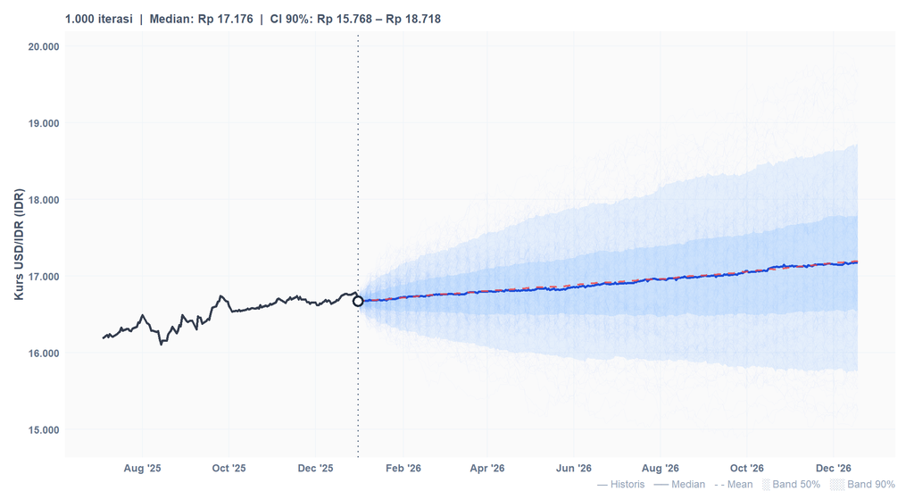

Fan chart simulasi Monte Carlo GBM — 1.000 iterasi

```r
p_fan_1000 <- buat_fan_chart(
  sim_matrix    = sim_1000,
  tanggal       = tanggal_sim,
  S0_kurs       = T0,
  n_sim_label   = "1.000",
  warna_jalur   = "#3b82f6",
  warna_median  = "#1d4ed8",
  warna_band    = "#93c5fd"
)
p_fan_1000
```

```r
# Simpan plot ke file
ggsave(
  filename = file.path(dir_plot, "fan_chart_1000_iterasi.png"),
  plot     = p_fan_1000,
  width    = 11, height = 6, units = "in", dpi = 300, bg = "white"
)
message("✅ Fan chart 1.000 iterasi disimpan.")
```